# 验证事件的时间间隔分布

- 泊松分布是二项分布p=0，N->$\infty$极限，平均值恒定为$\mu$=Np。泊松分布是一个随机过程，随机过程的特点是每个单位时间内发生的概率保持不变，也就是说下一个事件发生的概率与上一个事件的行为无关。泊松分布观察到r事件的概率  
  $\quad\quad\quad\quad\quad$ $P(r)=\frac{\mu^re^{(-\mu)}}{r!}$
- 假设放射源的平均计数率$\mu$=100，在t时间内观察到的平均事件数为$\mu$t。在t时间内没有观察到事件且在dt事件间隔内观察到事件的概率是$p=p(0)dp$,在dt时间间隔内观察到事件的概率$dp=\mu dt$,在t时间内没有观察到事件的概率$p(0)=\frac{\mu t^0e^{(-\mu t)}}{0!}$  
  $\quad\quad\quad\quad\quad$ $I_1(t)dt=\mu e^{(-\mu t)}dt$
- 所以，相邻事件时间间隔的分布函数为$I_1(t)=\mu e^{(-\mu t)}$。对此函数变形为$exp(p0+p1*x)$可用于拟合得到放射源的计数率$\mu$。
- 在t时间内观察到N-1个事件且在dt事件间隔内观察到事件的概率是$p=p(N-1)dp$,在dt时间间隔内观察到事件的概率$dp=\mu dt$,在t时间内观察到N-1个事件的概率$p(N-1)=\frac{(\mu t)^{N-1}e^{(-\mu t)}}{(N-1)!}$  
  $\quad\quad\quad\quad\quad$ $I_N(t)dt=\frac{(\mu t)^{N-1}e^{(-\mu t)}}{(N-1)!}\mu dt$
- 所以，相邻N个事件时间间隔的分布函数为$I_N(t)=\frac{(\mu t)^{N-1}e^{(-\mu t)}}{(N-1)!}\mu$。
- 例如，相邻两个事件时间间隔分布函数为$I_2(t)=\frac{(\mu t)^{1}e^{(-\mu t)}}{(1)!}\mu$。对此函数变形为$x*exp([p0]-[p1]*x)$可用于拟合得到放射源的计数率$\mu$。
- 随机事件的平均时间间隔与等间隔事件的平均时间间隔一样，均为N/$\mu$。N为相邻事件的个数，$\mu$为平均计数率。例如，相邻事件平均时间间隔为1/$\mu$,相邻两个事件的平均时间间隔为2/$\mu$。

```python
//%jsroot on
```

## 在0-trange的时间间隔内生成n个时间

```
unsorted random number:5135.87 4577.2 1017.27 8238.83 2445.03
```

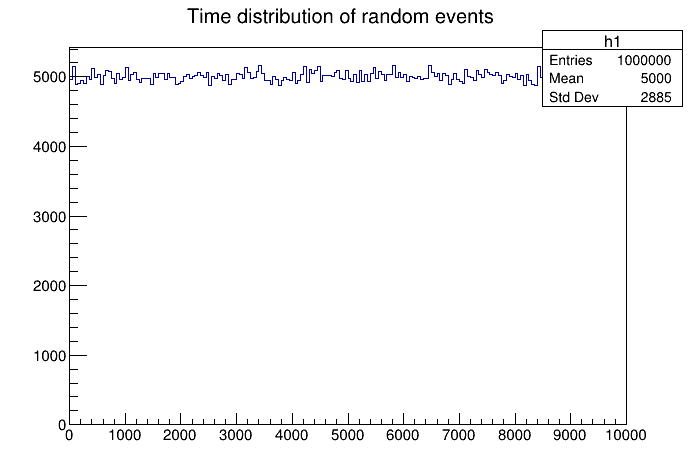

```
sorted random number:0.00215834 0.00794884 0.0264915 0.039984 0.0485848
```

```python
TCanvas c;
double mu=100;//average count per second
double trange=10000;//time interval - seconds
int n=mu*trange;//number of events;
auto h1=new TH1D("h1","Time distribution of random events",200,0,trange);
gRandom=new TRandom3(0);
vector<double> vt;
// generate n uniform random numbers
for(int i=0;i<n;i++) {
    double t=gRandom->Rndm()*trange;//n moment
    vt.push_back(t);
    h1->Fill(t);
}
cout<<"unsorted random number:";
for(int i=0;i<5;i++) cout<<vt[i]<<" ";
cout<<endl;
//sort random numbers in ascending order
sort(vt.begin(),vt.end());//sort vector in ascending order
cout<<"sorted random number:";
for(int i=0;i<5;i++) cout<<vt[i]<<" ";
cout<<endl;

h1->SetMinimum(0);
h1->Draw();
c.Draw();
```

# 计算相邻以及间隔n个事件之间的时间差分布

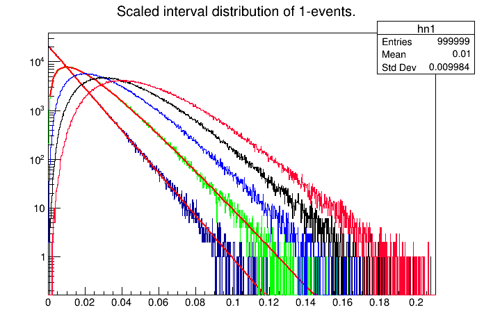

```
 FCN=537.153 FROM MIGRAD    STATUS=CONVERGED      67 CALLS          68 TOTAL
                     EDM=3.99765e-07    STRATEGY= 1      ERROR MATRIX ACCURATE
  EXT PARAMETER                                   STEP         FIRST
  NO.   NAME      VALUE            ERROR          SIZE      DERIVATIVE
   1  Constant     9.95346e+00   1.41016e-03   1.13305e-05  -3.91747e-01
   2  Slope       -1.00166e+02   9.96016e-02   8.00231e-04   4.15992e-03
 FCN=755.596 FROM MIGRAD    STATUS=CONVERGED      79 CALLS          80 TOTAL
                     EDM=8.54205e-11    STRATEGY= 1      ERROR MATRIX ACCURATE
  EXT PARAMETER                                   STEP         FIRST
  NO.   NAME      VALUE            ERROR          SIZE      DERIVATIVE
   1  p0           1.45595e+01   1.72518e-03   1.34359e-05  -1.07697e-02
   2  p1           1.00137e+02   7.03953e-02   5.48251e-04   1.09900e-04
```

```python
double xmax=3.0*7/mu;
//double dx=xmax/1000.;
TH1D *h[5];
for(int i=0;i<5;i++) {
    h[i]=new TH1D(Form("hn%d",i+1),Form("Scaled interval distribution of %d-events.",i+1),1000,0,xmax);
}

for(int i=0; i<vt.size();i++) {
    for(int j=1;j<=5;j++) {
        if(i>=j) h[j-1]->Fill(vt[i]-vt[i-j]);
    }
}
gPad->SetLogy();
h[0]->Draw();
h[0]->Fit("expo");//fit with function of f(x) = exp(p0+p1*x)
h[1]->SetLineColor(kGreen);
h[1]->Draw("same");
TF1 *f1 = new TF1("f1", "x*exp([p0]-[p1]*x)", 0, xmax);
f1->SetParameter(0, 10);
f1->SetParameter(1, 100);// 设置参数u的值，这里设为100
h[1]->Fit("f1");
h[2]->SetLineColor(kBlue);
h[2]->Draw("same");
h[3]->SetLineColor(kBlack);
h[3]->Draw("same");
h[4]->SetLineColor(kPink);
h[4]->Draw("same");
c.Draw();
```

end!